# Estudios de Informática, Multimedia y Telecomunicaciones

# Práctica 2: Limpieza y validación de los datos

Eduardo Ponce Palma

6 de enero de 2019

# 1 Introduccion

## 1.1 Presentacion

En esta práctica se elabora un caso práctico orientado a aprender a identificar los datos relevantes para un proyecto analítico y usar las herramientas de integración, limpieza, validación y análisis de las mismas. Para hacer esta práctica tendréis que trabajar en grupos de hasta 3 personas, o si preferís, también podéis hacerlo de manera individual. Tendréis que entregar un solo archivo con el enlace Github (https://github.com) donde se encuentren las soluciones incluyendo los nombres de los componentes del equipo. Podéis utilizar la Wiki de Github para describir vuestro equipo y los diferentes archivos que corresponden a vuestra entrega. Cada miembro del equipo tendrá que contribuir con su usuario Github. Podéis utilizar estos ejemplos como guía:

â?? Ejemplo: https://github.com/Bengis/nba-gap-cleaning

â?? Ejemplo complejo (archivo adjunto).

## 1.2 Competencias

En esta práctica se desarrollan las siguientes competencias del Máster de Data Science:

â?? Capacidad de analizar un problema en el nivel de abstracción adecuado a cada situación y aplicar las habilidades y conocimientos adquiridos para abordarlo y resolverlo.

â?? Capacidad para aplicar las técnicas específicas de tratamiento de datos (integración, transformación, limpieza y validación) para su posterior análisis.

## 1.3 Objetivos

Los objetivos concretos de esta prÃ¡ctica son:

â?? Aprender a aplicar los conocimientos adquiridos y su capacidad de resolución de problemas en entornos nuevos o poco conocidos dentro de contextos más amplios o multidisciplinares.

â?? Saber identificar los datos relevantes y los tratamientos necesarios (integración, limpieza y validación) para llevar a cabo un proyecto analítico.

â?? Aprender a analizar los datos adecuadamente para abordar la informaciÃ³n contenida en los datos.

â?? Identificar la mejor representación de los resultados para aportar conclusiones sobre el problema planteado en el proceso analítico.

â?? Actuar con los principios éticos y legales relacionados con la manipulación de datos en función del ámbito de aplicación.

â?? Desarrollar las habilidades de aprendizaje que les permitan continuar estudiando de un modo que tendrá que ser en gran medida autodirigido o autónomo.

â?? Desarrollar la capacidad de búsqueda, gestión y uso de información y recursos en el ámbito de la ciencia de datos.

# 2 Practica

## 2.1 DescripciÃ³n

Para esta practica se ha tomado un conjunto de datos “Video Game Sales with Ratings” de la pagina web de KAGGLE.COM, este dataset fue generado hasta la fecha del 22 de diciembre del 2016 y representa un conjunto de datos de juegos, sus caracteristicas, sus ventas en el mundo y puntuaciones de Metacritic.

### 2.1.1 El Dataset

El dataset se contituye de 16719 registros de 16 columna o atributos, se describen a continuacion:

> Name.- Name of the game

> Platform.- Console on which the game is running

> Year_of_Release.- AÃ±o de lanzamiento del juego

> Genre.- Categoria o genero del juego

> Publisher.- Empresa que lo publica

> NA_Sales.- Ventas en Norte America (en millones/unidades)

> EU_Sales.- Ventas en la Union Europea (en millones/unidades)

> JP_Sales.- Ventas en Japon (en millones/unidades)

> Other_Sales.- Ventas en el resto de mundo excepto las anteriores (en millones/unidades)

> Global_Sales.- Total de ventas en el mundo (en millones/unidades)

> Critic_Score.- PuntuaciÃ³n agregada del personal de Metacritic

> Critic_Count.- Numero de criticas dependientes de Critic_Score

> User_ScoreS.- PuntuaciÃ³n agregada de los suscriptores de Metacritic

> User_Count.- Numero de criticas dependientes de User_ScoreS

> Developer.- Desarrolladores del juego

> Rating.- La calificacion del juego (adolecentes, solo adultos, etc)

### 2.1.2 Importacia

En esta practica dado este conjunto de datos se pretende determinar que relacion tienen las ventas y las puntuaciones de Metacritic, se correlacionaran las variables para determinar si existe algun tipo de influencia.

Tambien se quiere determinar si los generos de mas popularidad en los ultimos 5 aÃ±os tienen una diferencia de ventas significativa entre ellos.

## 2.2 Integración y selección de los datos

En esta fase nos encargamos de extraer el dataset a ser examinado y cargamos los datos del archivo “VideoGames.csv”,

```r
vg <- read.csv('VideoGames.csv', stringsAsFactors = FALSE)
```

Selecionamos los datos de interes y descartartamos las columnas que no necesitamos ya que no influyen para el proposito del analisis, luego verificamos la estructura del juego de datos.

```r
vg$Name <- NULL
vg$Publisher <- NULL
vg$Developer <- NULL
vg$Rating <- NULL
str(vg)
```

```
## 'data.frame':    16719 obs. of  12 variables:
##  $ Platform       : chr  "Wii" "NES" "Wii" "Wii" ...
##  $ Year_of_Release: chr  "2006" "1985" "2008" "2009" ...
##  $ Genre          : chr  "Sports" "Platform" "Racing" "Sports" ...
##  $ NA_Sales       : num  41.4 29.1 15.7 15.6 11.3 ...
##  $ EU_Sales       : num  28.96 3.58 12.76 10.93 8.89 ...
##  $ JP_Sales       : num  3.77 6.81 3.79 3.28 10.22 ...
##  $ Other_Sales    : num  8.45 0.77 3.29 2.95 1 0.58 2.88 2.84 2.24 0.47 ...
##  $ Global_Sales   : num  82.5 40.2 35.5 32.8 31.4 ...
##  $ Critic_Score   : int  76 NA 82 80 NA NA 89 58 87 NA ...
##  $ Critic_Count   : int  51 NA 73 73 NA NA 65 41 80 NA ...
##  $ User_Score     : chr  "8" "" "8.3" "8" ...
##  $ User_Count     : int  322 NA 709 192 NA NA 431 129 594 NA ...
```

## 2.3 Limpieza de los datos

En esta fase se tratara de resolver los datos no consistentes o datos no validos, primero se verificara que columnas los contienen.

```r
colSums(is.na(vg))
```

```
##        Platform Year_of_Release           Genre        NA_Sales
##               0               0               0               0
##        EU_Sales        JP_Sales     Other_Sales    Global_Sales
##               0               0               0               0
##    Critic_Score    Critic_Count      User_Score      User_Count
##            8582            8582               0            9129
```

```r
colSums(vg=="N/A")
```

```
##        Platform Year_of_Release           Genre        NA_Sales
##               0             269               0               0
##        EU_Sales        JP_Sales     Other_Sales    Global_Sales
##               0               0               0               0
##    Critic_Score    Critic_Count      User_Score      User_Count
##              NA              NA               0              NA
```

```r
colSums(vg=="0")
```

```
##        Platform Year_of_Release           Genre        NA_Sales
##               0               0               0            4511
##        EU_Sales        JP_Sales     Other_Sales    Global_Sales
##            5874           10515            6604               0
##    Critic_Score    Critic_Count      User_Score      User_Count
##              NA              NA               1              NA
```

```r
colSums(vg=="")
```

```
##        Platform Year_of_Release           Genre        NA_Sales
##               0               0               2               0
##        EU_Sales        JP_Sales     Other_Sales    Global_Sales
##               0               0               0               0
##    Critic_Score    Critic_Count      User_Score      User_Count
##              NA              NA            6704              NA
```

Los demas valores extremos identificados corresponden a valores de sumatorias de ventas o numeros de criticas y por ende son valores reales posibles.

Mostraremos para cada atributo los valores mediante la funcion summary.

```r
vg <- vg[vg$Year_of_Release<=2016,]
vg$Year_of_Release[vg$Year_of_Release=="N/A"]=NA
vg$Year_of_Release <- as.integer(vg$Year_of_Release)
vg$Year_of_Release[is.na(vg$Year_of_Release)] <- median(vg$Year_of_Release,na.rm=T)

vg$Genre[vg$Genre==""]="S/G"

vg$User_Score[vg$User_Score=="tbd"]=NA
vg$User_Score <- as.integer(vg$User_Score)

summary(vg)
```

```
##    Platform         Year_of_Release    Genre              NA_Sales
##  Length:16446       Min.   :1980    Length:16446       Min.   : 0.0000
##  Class :character   1st Qu.:2003    Class :character   1st Qu.: 0.0000
##  Mode  :character   Median :2007    Mode  :character   Median : 0.0800
##                     Mean   :2006                       Mean   : 0.2641
##                     3rd Qu.:2010                       3rd Qu.: 0.2400
##                     Max.   :2016                       Max.   :41.3600
##
##     EU_Sales          JP_Sales         Other_Sales        Global_Sales
##  Min.   : 0.0000   Min.   : 0.00000   Min.   : 0.00000   Min.   : 0.0100
##  1st Qu.: 0.0000   1st Qu.: 0.00000   1st Qu.: 0.00000   1st Qu.: 0.0600
##  Median : 0.0200   Median : 0.00000   Median : 0.01000   Median : 0.1700
##  Mean   : 0.1459   Mean   : 0.07848   Mean   : 0.04759   Mean   : 0.5364
##  3rd Qu.: 0.1100   3rd Qu.: 0.04000   3rd Qu.: 0.03000   3rd Qu.: 0.4700
##  Max.   :28.9600   Max.   :10.22000   Max.   :10.57000   Max.   :82.5300
##
##   Critic_Score    Critic_Count      User_Score     User_Count
##  Min.   :13.00   Min.   :  3.00   Min.   :0.00   Min.   :    4
##  1st Qu.:60.00   1st Qu.: 12.00   1st Qu.:6.00   1st Qu.:   10
##  Median :71.00   Median : 22.00   Median :7.00   Median :   24
##  Mean   :68.99   Mean   : 26.44   Mean   :6.68   Mean   :  163
##  3rd Qu.:79.00   3rd Qu.: 36.00   3rd Qu.:8.00   3rd Qu.:   81
##  Max.   :98.00   Max.   :113.00   Max.   :9.00   Max.   :10665
##  NA's   :8463    NA's   :8463     NA's   :8983   NA's   :8983
```

Adicionamente exportamos el dataset generado despues de la limpieza de datos

```r
write.csv(vg, "VideoGamesClean.csv")
```

## 2.4 AnÃ¡lisis de los datos

En esta fase se realizaran los proceso de analisis para poder responder a las preguntas planteadas en el inicio de la practica.

### 2.4.1 SelecciÃ³n de grupos

En esta fase selecionamos a los juegos publicados desde el 2011, para poder observar la tendencia de los ultimos aÃ±os de desarrollo de juegos respecto al genero, no se tomara en cuenta la plataforma puesto que es cambiante y cada cierto tiempo hay nuevas consolas.

```r
vg_5y <- vg[vg$Year_of_Release>2010,]
summary(vg_5y)
```

```
##    Platform         Year_of_Release    Genre              NA_Sales
##  Length:4022        Min.   :2011    Length:4022        Min.   :0.0000
##  Class :character   1st Qu.:2011    Class :character   1st Qu.:0.0000
##  Mode  :character   Median :2013    Mode  :character   Median :0.0400
##                     Mean   :2013                       Mean   :0.2063
##                     3rd Qu.:2015                       3rd Qu.:0.1700
##                     Max.   :2016                       Max.   :9.6600
##
##     EU_Sales         JP_Sales        Other_Sales       Global_Sales
##  Min.   :0.0000   Min.   :0.00000   Min.   :0.00000   Min.   : 0.010
##  1st Qu.:0.0000   1st Qu.:0.00000   1st Qu.:0.00000   1st Qu.: 0.040
##  Median :0.0300   Median :0.00000   Median :0.01000   Median : 0.130
##  Mean   :0.1665   Mean   :0.06108   Mean   :0.05194   Mean   : 0.486
##  3rd Qu.:0.1300   3rd Qu.:0.05000   3rd Qu.:0.04000   3rd Qu.: 0.400
##  Max.   :9.0900   Max.   :4.39000   Max.   :3.96000   Max.   :21.040
##
##   Critic_Score    Critic_Count      User_Score      User_Count
##  Min.   :13.00   Min.   :  3.00   Min.   :0.000   Min.   :    4.0
##  1st Qu.:64.00   1st Qu.: 13.00   1st Qu.:5.000   1st Qu.:   23.0
##  Median :74.00   Median : 27.00   Median :7.000   Median :   74.0
##  Mean   :71.27   Mean   : 31.72   Mean   :6.191   Mean   :  347.4
##  3rd Qu.:81.00   3rd Qu.: 46.00   3rd Qu.:7.000   3rd Qu.:  278.2
##  Max.   :97.00   Max.   :113.00   Max.   :9.000   Max.   :10665.0
##  NA's   :2210    NA's   :2210     NA's   :1990    NA's   :1990
```

```r
str(vg_5y)
```

```
## 'data.frame':    4022 obs. of  12 variables:
##  $ Platform       : chr  "PS3" "X360" "X360" "PS4" ...
##  $ Year_of_Release: num  2013 2013 2011 2015 2013 ...
##  $ Genre          : chr  "Action" "Action" "Shooter" "Shooter" ...
##  $ NA_Sales       : num  7.02 9.66 9.04 6.03 5.28 4.99 8.25 5.54 5.03 3.96 ...
##  $ EU_Sales       : num  9.09 5.14 4.24 5.86 4.19 5.73 4.24 5.73 4.02 6.31 ...
##  $ JP_Sales       : num  0.98 0.06 0.13 0.36 4.35 0.65 0.07 0.49 2.69 0.38 ...
##  $ Other_Sales    : num  3.96 1.41 1.32 2.38 0.78 2.42 1.12 1.57 0.91 1.97 ...
##  $ Global_Sales   : num  21 16.3 14.7 14.6 14.6 ...
##  $ Critic_Score   : int  97 97 88 NA NA 83 83 88 85 97 ...
##  $ Critic_Count   : int  50 58 81 NA NA 21 73 39 73 66 ...
##  $ User_Score     : int  8 8 3 NA NA 5 4 3 8 8 ...
##  $ User_Count     : int  3994 3711 8713 NA NA 922 2256 5234 632 2899 ...
```

Selecionamos los 3 primeros generos que son “Action”, “Role-Playing” y “Adventure” cada uno en un subconjunto.

```r
vg_Genero1 <- vg_5y[vg_5y$Genre == "Action",]$Global_Sales
vg_Genero2 <- vg_5y[vg_5y$Genre == "Role-Playing",]$Global_Sales
vg_Genero3 <- vg_5y[vg_5y$Genre == "Adventure",]$Global_Sales
```

### 2.4.2 ComprobaciÃ³n de la normalidad y homogeneidad de la varianza

Se comprueba si existe atributos con distribucion normal y utilizamos la prueba de AndersonDarling ya que la muestra es mayor a 5000 registros. Se fija Î± = 0.05, este algoritmo fue tomado del ejemplo de la practica.

```r
library(nortest)
alpha = 0.05
col.names = colnames(vg)
for (i in 1:ncol(vg)) {
  if (i == 1) cat("Variables que no siguen una distribuciÃ³n normal:\n")

  if (is.integer(vg[,i]) | is.numeric(vg[,i])) {
    p_val = ad.test(vg[,i])$p.value
    if (p_val < alpha) {
      cat(col.names[i])
      # Format output
      if (i < ncol(vg) - 1) cat(", ")
      if (i %% 3 == 0) cat("\n")
    }
  }
}
```

```
## Variables que no siguen una distribuciÃ³n normal:
## Year_of_Release, NA_Sales, EU_Sales, JP_Sales,
## Other_Sales, Global_Sales, Critic_Score,
## Critic_Count, User_ScoreUser_Count
```

En este caso ningun atributo siguió la distribucion normal y por esta razón no se puede realizar la homogeneidad de la varianza.

Aqui una prueba de que el valor de “p-value” tiene de a cero

```r
vg$Platform <- as.factor(vg$Platform)
fligner.test(Year_of_Release ~ Platform, data = vg)
```

```
##
##  Fligner-Killeen test of homogeneity of variances
##
## data:  Year_of_Release by Platform
## Fligner-Killeen:med chi-squared = 2841.9, df = 30, p-value <
## 2.2e-16
```

Se muestra que el valor de p-value es menor a 0.05

### 2.4.3 Aplicación de pruebas estadísticas

En esta fase creamos una matriz de correlacion entre la variables numericas para determinar si existe una relacion entre la muestras,

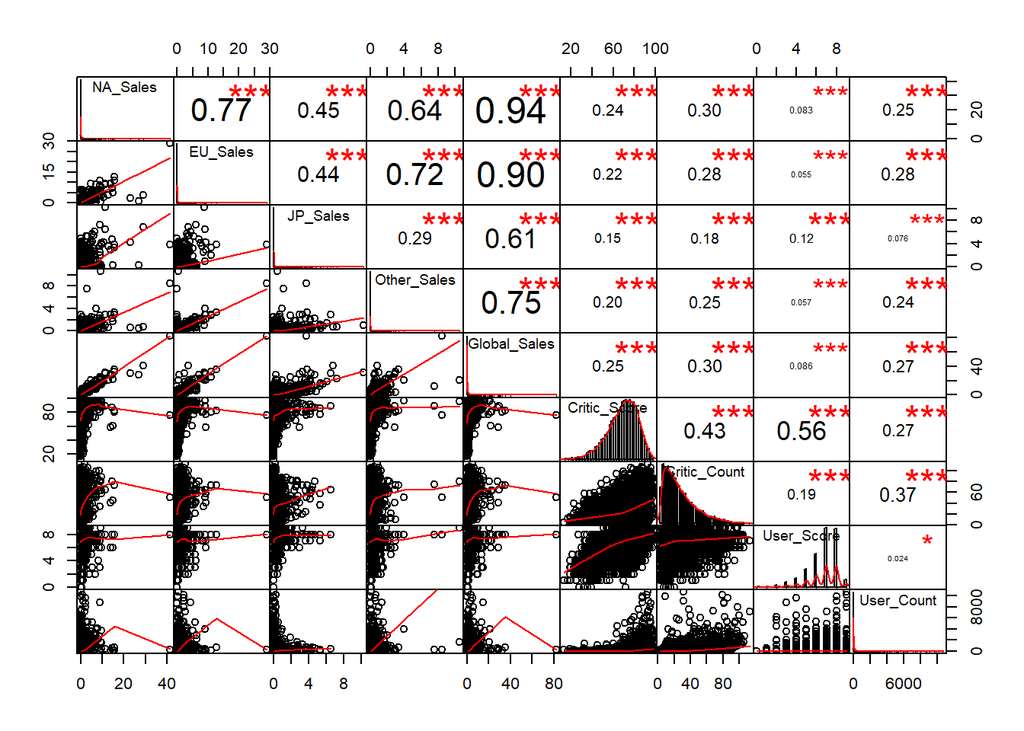

```r
library(PerformanceAnalytics)
vg_grupo <- vg[,4:12]
#vg_grupo <- na.omit(vg_grupo)
chart.Correlation(vg_grupo)
```

Aplicado la matriz podemos decir que existe una fuerte relacion entre la venta generadas en NA_Sales y EU_Sales contra Global_Sales, que las ventas tiene poca relacion con la puntuaciones de Critic_Score y casi nula con las puntuaciones de User_Score

Tambien se realizan pruebas de comparaciÃ³n entre los 3 primeros generos de mayor popularidad desde el 2011.

```r
t.test(vg_Genero1, vg_Genero2,alternative = "less")
```

```
##
##  Welch Two Sample t-test
##
## data:  vg_Genero1 and vg_Genero2
## t = -1.2975, df = 731.86, p-value = 0.09743
## alternative hypothesis: true difference in means is less than 0
## 95 percent confidence interval:
##        -Inf 0.02378093
## sample estimates:
## mean of x mean of y
## 0.4397163 0.5280215
```

```r
t.test(vg_Genero1, vg_Genero3,alternative = "less")
```

```
##
##  Welch Two Sample t-test
##
## data:  vg_Genero1 and vg_Genero3
## t = 9.588, df = 1616.3, p-value = 1
## alternative hypothesis: true difference in means is less than 0
## 95 percent confidence interval:
##       -Inf 0.3863987
## sample estimates:
## mean of x mean of y
## 0.4397163 0.1099268
```

```r
t.test(vg_Genero2, vg_Genero3,alternative = "less")
```

```
##
##  Welch Two Sample t-test
##
## data:  vg_Genero2 and vg_Genero3
## t = 6.7568, df = 512.16, p-value = 1
## alternative hypothesis: true difference in means is less than 0
## 95 percent confidence interval:
##       -Inf 0.5200591
## sample estimates:
## mean of x mean of y
## 0.5280215 0.1099268
```

## 2.5 resultados

Mostramos los resultados del atributo “Year_of_Release” para ver graficamente que no existe distribucion normal y que la homogeneidad de la varianza del mismo respecto a la plataforma no se da el resultado.

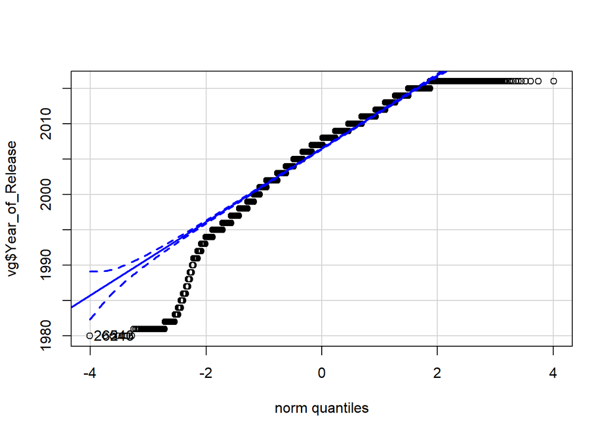

```
## [1] 262 543
```

```r
# distribucion no normal
library("car")
library(ggplot2)
qqPlot(vg$Year_of_Release)
```

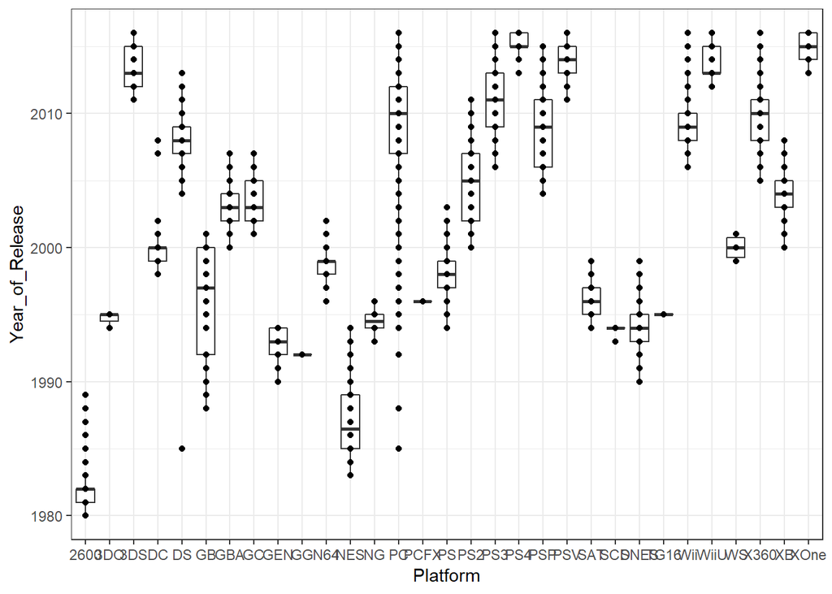

```r
# homogeneidad de la varianza
ggplot(data = vg, aes(x = Platform, y = Year_of_Release)) +  geom_boxplot() + geom_point() +  theme_bw() +  theme(legend.position = "none")
```